# Week 5

Peter Dolan

9/22/2019

I want to ensure that we cover all the material that I have planned so I’m going to give a bit less exposure to Python than I had originally planned. I’ll spend half a day on Monday going over some more sophisticated Python structures.

## Vocabulary

A data structure is **immutable** if its value can not be changed. R treats a surprisingly large number of objects as immutable… kinda.. sorta. For example:

```r
#R
my.array=c("first","second")
bob=function(arr){
  arr[1]="different first"
  return(arr)
}
output=bob(my.array)
output
```

```
## [1] "different first" "second"
```

```r
my.array
```

```
## [1] "first"  "second"
```

Notice that the value of `my.array` has not, in fact, been changed.

- R **copies** the value of associated first parameter in the function call `bob` (in our case it copies `my.array`). This is attached to the argument variable `arr`. When `arr` is returned, another copy is made and assigned to `output`. This *could* be terrible for memory usage, but R uses **lazy evaluation**.. which means the copy doesn’t actually occur until it is needed.

```python
#Python
myArray=["First","Second"]
def bob(arr):
    arr[0]="Different First"
    return(arr)

output=bob(myArray)
output
```

```
## ['Different First', 'Second']
```

```python
myArray
```

```
## ['Different First', 'Second']
```

Notice that in this example `myArray` **has changed**. Even moreso:

```python
#Python
output is myArray
```

```
## True
```

The two variables `output` and `myArray` are referring to the same location in memory! **BE CAREFUL**. These differences are huge.

## Data Structures

We are going to mix terminology from the two languages here. These are the terminologies that I will use:

- **Strings:** Character data
- **Tuple:** An immutable ordered sequence of objects
- **List:** A mutable ordered sequence of objects
- **Array:** A mutable ordered sequence of *things* of the same type ( a `vector` in R)
- **Set:** A collection of objects without repeats
- **Associative Array:** A mutable sequence of *things* indexed by **strings**
  - Implemented by assigning a `names` attribute to a vector in R
  - Implemented as a `dict` in Python

## Python Data Structures

### Lists

Lists in Python are similar to lists in R although the syntax for a Python list is closer to the syntax for an R vector.

```python
#python
array=['first','second',10,30]
array[1] #this is the SECOND entry
```

```
## 'second'
```

```python
array[1:3] #This returns the second, and third but NOT fourth entry in the array
```

```
## ['second', 10]
```

```python
array[1:] #From second entry to end
```

```
## ['second', 10, 30]
```

```python
array[:2] #From start to second entry.
```

```
## ['first', 'second']
```

```python
array[-1] #Last entry
```

```
## 30
```

```python
array[-2] #Second to last entry
```

```
## 10
```

### Tuples

The first is a tuple– it can be surrounded by parenthesis, but does not need to be. The entries are **immutable**– they can’t be changed:

```python
example=3,4,'a'
example2=(3,4,('a',10),4)
example[0]
```

```
## 3
```

```python
example2[0]
```

```
## 3
```

```python
example2[2]
```

```
## ('a', 10)
```

```python
example2[2][1]
#example2[0][0]  #this would generate an error
#example[1]=2    # this would generate an error too
```

```
## 10
```

### Dictionaries

These are key-value pairs– otherwise known as an associative array. Python uses `{` and `}` (very similar to JSON). Notice the `:`

```python
#Python
ageLookup={'Peter': 48, 'Heather': 35, 'Amy': 40, 'Zet': 11}
ageLookup["Peter"]
## Adding
```

```
## 48
```

```python
ageLookup["Ollie"]=110 #Adding a new value
ageLookup
## Removing
```

```
## {'Peter': 48, 'Heather': 35, 'Amy': 40, 'Zet': 11, 'Ollie': 110}
```

```python
del ageLookup["Ollie"]
ageLookup
## Looking for a key
```

```
## {'Peter': 48, 'Heather': 35, 'Amy': 40, 'Zet': 11}
```

```python
"Peter" in ageLookup
```

```
## True
```

```python
"Ollie" in ageLookup

#Iterating over keys with a `for` loop:
```

```
## False
```

```python
for key in ageLookup:
  print(key)
#Iterating over key-value pairs with a `for` loop (notice the .items() method):
```

```
## Peter
## Heather
## Amy
## Zet
```

```python
for key,value in ageLookup.items():
  print(key,"->",value)
```

```
## Peter -> 48
## Heather -> 35
## Amy -> 40
## Zet -> 11
```

In R we use the `names` attribute:

```r
#R
age.lookup<-c(Peter=48,Heather=35,Amy=40,Zet=11) # Method 1
age.lookup["Peter"]
```

```
## Peter
##    48
```

```r
#or
age.lookup=c(48,35,40,11) # Method 2
names(age.lookup)=c("Peter","Heather","Amy","Zet")
age.lookup["Peter"]
```

```
## Peter
##    48
```

### Sets

These capture the mathematical idea of a set. In otherwords the abstraction of **categorization**.

(I’ll probably do a big spiel on this in class)

**In Python:** they use the `{` and `}` similarly to how sets are defined in mathematics. The difference between a `dict` and a `set` is in whether or not there is a key.

```python
#python
A = {1,2,3}
B={2,2,3,1,3}
A==B #True
```

```
## True
```

**Adding elements:**

```python
#python
C={1,2,3}
C.add(5)
C
```

```
## {1, 2, 3, 5}
```

**Removing elements:**

```python
#python
C.discard(5)
C
#Can also use .remove()... but that throws an error if the elt is not present.  .discard() does not.
```

```
## {1, 2, 3}
```

$\left|A\right|$ is found using `len(A)`:

```python
#python
len(A)
```

```
## 3
```

```python
A.add(3)
len(A) # doesnt' change because 3 is already in A
```

```
## 3
```

We can use `in` and `not in` to detect membership and lack of membership:

```python
#python
3 in A
```

```
## True
```

```python
5 in A
```

```
## False
```

We can iterate over elements with `for`:

```python
#python
for elt in A:
   print(elt)
```

```
## 1
## 2
## 3
```

```python
B={2,3,4,5}
```

**Set operations:**

Here is a non-exhaustive list of some set operations:

[output not shown]

**Warning:** Some mathematicians use $A \subset B$ to mean $A \subseteq B$, and $A \varsubsetneq B$ to denote a **proper** subset.

Also:

```python
# python
A={1,2,3}
B={1,2,3}
A==B #True... same contents
```

```
## True
```

```python
A is B # False... different objects
```

```
## False
```

```python
C=A
C is A # True same object... so changing one changes the other.
```

```
## True
```

```python
C.discard(3)
A #A not longer has a 3
```

```
## {1, 2}
```

There is no analog in R, although there are set-based operations. Without knowing the **universe** the **complement** operation can’t be performed, but if there is a universal set of some sort (call it U) then the `setdiff` function can generate the complement.

- `unique()`
- `setdiff(A,B)`
- `union(A,B)`
- `intersect(A,B)`
- `setequal(x,y)`
- `is.element(e1,set)`

## Sequences

In Python, `lists`, `tuples`, and `strings` are sequencs (the latter is a sequence of characters). It can be **sliced** similarly to any other sequence:

```python
# python
string="My Test String"
string[1] #The second character
```

```
## 'y'
```

```python
string[-1] #The last character
```

```
## 'g'
```

```python
string[:3] #The first three characters (indices 0 up to, but not including 3)
```

```
## 'My '
```

#Importing data into Python

Python allows files to be opened using the `open()` function. The `as` keyword associates the file to a variable and allows for processing. For example:

```python
#Python
import os
cwd = os.getcwd()
print(cwd)
```

```
## /home/dolanp/dsci3701/Lectures/Week 5
```

```python
d={}

with open("test") as f:
  for line in f:
    (val,key)=line.split(",")
    d[key.strip()]=val.strip()
for x in list(d)[0:3]:
    print("key:  ->{}<-\nvalue ->{}<- ".format(x,d[x]))
```

```
## key:  ->Verne Troyer<-
## value ->2′ 8″<-
## key:  ->Emmanuel Lewis<-
## value ->3′ 4″<-
## key:  ->Matthew Roloff<-
## value ->4′ 2″<-
```

# Numeric

Let’s discuss the background on regression. To begin with, we will examine the New York air quality example in the Regression I tutorial.

I will review in class:

- Making a linear model
- Interpreting the coefficients
- Checking the diagnostic plots

Theory:

$$\textrm{DATA} = \textrm{FIT} + \textrm{RESIDUAL}$$

Futhermore

$$\textrm{RESIDUAL} \sim N(0,\sigma^2)$$

Our usual regression approach attempts to minimize the **sum of the squared residuals**. This creates a model that tries to predict the location of the **mean** of the response variable **conditioned upon** the combination of explanatory values.

We could, however, try to minimize **different** functions.

**NOTE:** Some regression techniques standardize the values before performing the regression.

**NOTE 2:** Ridge regression uses $L2$ regularization and Lasoo regression uses $L1$ regularization. The term $\lambda$ is known as a **hyper parameter**.

| Function | Effect |
| --- | --- |
| $\sum\left(\textrm{RESIDUAL}_i\right)^2$ | Estimates $\mathbb{E}(Y\|X)$ |
| $\sum\biggl\|\textrm{RESIDUALS__i}\biggr\|$ | Estimates $\textrm{Median}(Y\|X)$ |
| $\sum\left(\textrm{RESIDUAL}_i\right)^2\ + \lambda\sum b_i^2$ | Helps stabilize coefficient values– particularly helpful when explanatory variables have high colinearity |
| $\sum\left(\textrm{RESIDUAL}_i\right)^2\ + \lambda\sum \left\|b_i\right\|$ | Automatically performs variable selection. |

You can see some interactive examples in the Week 5b document.

Notice the key thing here is **minimizing a cost function**.

Almost every technique that we will examine will do this. A careful choice of cost function will help ensure that the solutions you provide will be an accurate (or as close as you can get) reflection of the true problem and its solution.

## On colinearity.

Consider this model:

$$\widehat{Y} = 10 + 2X_1 - 3 X_2$$
Now… Think about a calculation for $\widehat{Y}$. Let’s suppose $X_1 = 3$ and $X_2 = 3$:

$$\begin{aligned}
\widehat{Y} &= 10 + 2 X_1 - 3 X_2\\
&= 10 + 2(3) - 3(3)\\
&= 7
\end{aligned}$$
Nothing tricky there… however… what if $X_2$ is ALWAYS the same value as $X_1$? Then the expression collapses:

$$\begin{aligned}
\widehat{Y} &= 10 + 2 X_1 - 3 X_2\\
&= 10 + 2 X_1 - 3 X_1\\
&= 10 +(2-3)X_1\\
&= 10 - X_1
\end{aligned}$$
This is an extreme form of collinearity… if I don’t know that this relationship exists then **any** model of the following form will make the **exact same prediction** for the given $X_1$ and $X_2$ data:

$$\widehat{Y} = 10 + aX_1 + bX_2 \qquad\textrm{where }a+b = 2+(-3) = -1$$

In general the standard error of a coefficient for an explantory variable will be BIGGER if it is correlated with another explanatory variable. It’s actually capturing the idea of what you’re seeing above… we don’t change things by shifting value back and forth between $a$ and $b$.

Let’s look at what effect *nearly* linear might be:

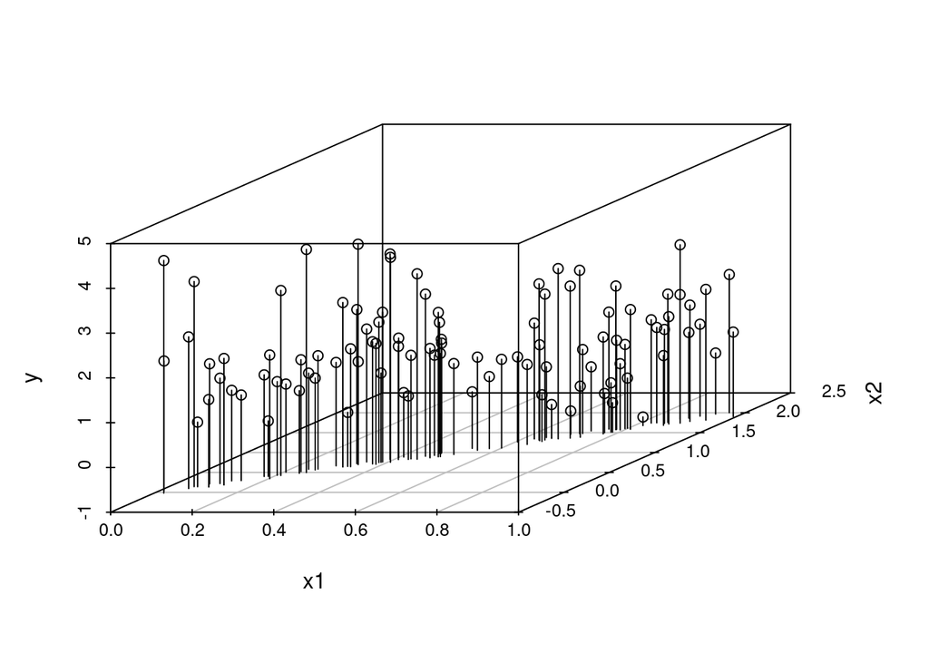

```r
library(scatterplot3d)
set.seed(1) # Ensure we get the same values:
x1=runif(100)
#x2=runif(100)
x2=2*x1+runif(100,-0.1,0.1)
y=2+3*x1 - 2*x2 +rnorm(100,0,1)
scatterplot3d(x1,x2,y,type="h")
```

```r
summary(lm(y~x1+x2))
```

```
##
## Call:
## lm(formula = y ~ x1 + x2)
##
## Residuals:
##     Min      1Q  Median      3Q     Max
## -1.8579 -0.6167 -0.1432  0.5352  2.3318
##
## Coefficients:
##             Estimate Std. Error t value Pr(>|t|)
## (Intercept)   1.9978     0.2116   9.441 2.17e-15 ***
## x1            2.7872     3.6025   0.774    0.441
## x2           -1.9282     1.7889  -1.078    0.284
## ---
## Signif. codes:  0 '***' 0.001 '**' 0.01 '*' 0.05 '.' 0.1 ' ' 1
##
## Residual standard error: 0.9675 on 97 degrees of freedom
## Multiple R-squared:  0.09285,    Adjusted R-squared:  0.07414
## F-statistic: 4.964 on 2 and 97 DF,  p-value: 0.008861
```